# Saliency e Atribuição em Redes Neurais

Interpretabilidade de Aprendizado de Máquina

**[Bruno Iochins Grisci](https://brunogrisci.github.io/)**

[Universidade Federal do Rio Grande do Sul](https://www.ufrgs.br/site/)  
[Instituto de Informática](https://www.inf.ufrgs.br/site/)  
[Departamento de Informática Teórica](https://www.inf.ufrgs.br/site/estrutura/departamentos/)  
[Programa de Pós-Graduação em Computação](https://www.inf.ufrgs.br/ppgc/)

## Aula anterior

**[Aula 14: Visualização de Features e Detecção de Conceitos](https://brunogrisci.github.io/aulas-interpretabilidade/aula14.html)**

## Bibliografia

- **Interpretable Machine Learning**. Christoph Molnar. 3. ed., 2025. Capítulo [*Saliency Maps*](https://christophm.github.io/interpretable-ml-book/pixel-attribution.html).
- **Grad-CAM: Visual Explanations from Deep Networks via Gradient-based Localization**. Ramprasaath R. Selvaraju *et al.* *International Journal of Computer Vision*, 2020. [doi:10.1007/s11263-019-01228-7](https://doi.org/10.1007/s11263-019-01228-7)
- **Methods for Interpreting and Understanding Deep Neural Networks**. Grégoire Montavon, Wojciech Samek e Klaus-Robert Müller. *Digital Signal Processing*, 2018. [doi:10.1016/j.dsp.2017.10.011](https://doi.org/10.1016/j.dsp.2017.10.011)

Além dos artigos originais de cada método, citados em cada slide.

[figure not shown]

# Saliency maps

## Por que esta imagem recebeu esta classe?

**Relembrando a [Aula 14](https://brunogrisci.github.io/aulas-interpretabilidade/aula14.html):** feature visualization perguntava o que uma unidade da rede detecta — uma pergunta *global*. Hoje a pergunta é *local*: nesta imagem, o que levou a rede a esta classe?

**imagem**  
um cachorro e um gato

mapa para a classe **“gato”**

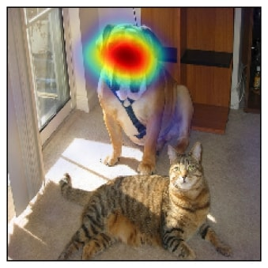

mapa para a classe **“buldogue”**

Um saliency map pinta cada pixel com a sua relevância para **uma** decisão sobre **uma** imagem: a mesma foto tem um mapa para cada classe que se queira explicar.

**Para que servem:** validar um modelo — um classificador de cavalos olhava a marca d’água de copyright das fotos, um Clever Hans ([Aula 03](https://brunogrisci.github.io/aulas-interpretabilidade/aula03.html)) —, achar vieses e gerar hipóteses em dados científicos.

Grad-CAM na VGG-16 treinada no ImageNet (vermelho: mais relevante): [Selvaraju *et al.* (2020)](https://doi.org/10.1007/s11263-019-01228-7), fig. 1a, 1c e 1i, reproduzidas para fins didáticos. Cavalos e copyright: Lapuschkin *et al.* (2016), em [Montavon, Samek e Müller (2018)](https://doi.org/10.1016/j.dsp.2017.10.011), §8.1 e fig. 9b.

## O que é um saliency map

[figure not shown]

$$S(\mathbf x)=\big[S_1(\mathbf x),\ldots,S_C(\mathbf x)\big]
\qquad\longrightarrow\qquad
\mathbf R^c=\big[R^c_1,\ldots,R^c_p\big]$$

**$\mathbf x\in\mathbb R^p$**

A entrada, com $p$ atributos: pixels (aqui, 784), palavras ou colunas de uma tabela.

**$S_c(\mathbf x)$**

O escore que a rede dá à classe $c$; numa regressão, $C=1$.

**$c$**

A classe explicada: em geral a prevista, mas pode ser qualquer uma.

**$R^c_i$**

A relevância do atributo $i$ para $S_c$: positiva (a favor), negativa (contra) ou perto de 0.

**$\mathbf R^c$**

O mapa: um número por atributo, do tamanho da entrada.

É um caso de **feature attribution**, como LIME ([Aula 07](https://brunogrisci.github.io/aulas-interpretabilidade/aula07.html)) e SHAP ([Aula 09](https://brunogrisci.github.io/aulas-interpretabilidade/aula09.html)): uma explicação local, pós-treino, de uma predição. Em imagens, os atributos são os pixels.

Notação de [Molnar (2025), *Saliency Maps*](https://christophm.github.io/interpretable-ml-book/pixel-attribution.html). Figura: um 3 do MNIST (imagem de teste 18) e o seu mapa pelo Vanilla Gradient, que veremos adiante, na CNN da aula.

## Muitos nomes para a mesma ideia

saliency mapsensitivity mappixel attributionattribution mapheatmaprelevance mapfeature attributionfeature relevancefeature contributiongradient-based attributionlocalization mapexplanation map

Em português: mapa de saliência, de relevância ou de atribuição. Neste curso, *saliency map* para o mapa e *atribuição* para o número de cada pixel.

**Por que tantos nomes**

Cada grupo nomeou o seu método: Simonyan *et al.* falavam em *saliency*; Bach *et al.*, em *relevance*; Selvaraju *et al.*, em *localization map*. A biblioteca iNNvestigate evita “explicar” e diz só que os métodos *analisam* a rede.

**Cuidado: “saliência” já existia**

Em visão computacional, *saliency map* também é um modelo da atenção **humana**: onde uma pessoa olharia numa cena. Aqui não há pessoas: o mapa descreve a rede.

Nomes: [Molnar (2025)](https://christophm.github.io/interpretable-ml-book/pixel-attribution.html); [Simonyan, Vedaldi e Zisserman (2014)](https://arxiv.org/abs/1312.6034); [Bach *et al.* (2015)](https://doi.org/10.1371/journal.pone.0130140); [Selvaraju *et al.* (2020)](https://doi.org/10.1007/s11263-019-01228-7); [Alber *et al.* (2019)](https://jmlr.org/papers/v20/18-540.html), p. 3. Atenção visual: [Itti, Koch e Niebur (1998)](https://doi.org/10.1109/34.730558).

## Como organizar os métodos

[figure not shown]

**Como o método consulta a rede?**

Perturbando partes da imagem e vendo a saída mudar (oclusão, LIME, SHAP: agnósticos) ou retropropagando um sinal pela rede (específicos de redes neurais, uma passada para frente e uma para trás).

**Em relação a quê?**

**Só gradiente**: “se eu aumentasse este pixel, o escore subiria ou desceria?”. **Com referência**: divide-se a diferença $S_c(\mathbf x)-S_c(\mathbf x')$ entre os pixels, com $\mathbf x'$ uma imagem “neutra” (preta, cinza…).

As duas classificações são de [Molnar (2025)](https://christophm.github.io/interpretable-ml-book/pixel-attribution.html), que chama os métodos com referência de *path-attribution methods*.

## Estão em toda parte

[figure not shown]

**Muito usados**

“Saliency methods have emerged as a popular tool” (Adebayo *et al.*). Bibliotecas como Captum, iNNvestigate e tf-keras-vis implementam dezenas deles; o Grad-CAM é mencionado em milhares de trabalhos por ano.

**Métodos demais?**

“There’s a confusing amount of pixel attribution approaches” — e um apelo: “please, no more invention of new saliency methods, but more scrutiny of how to evaluate them” (Molnar). A avaliação é o tema do fim da [Aula 16](https://brunogrisci.github.io/aulas-interpretabilidade/aula16.html).

Trabalhos indexados no [OpenAlex](https://openalex.org/) com o nome do método no título ou no resumo, por ano de publicação (consulta em 03/10/2026; a cobertura de resumos cresce nos anos recentes, então a tendência vale mais que o número exato). [Adebayo *et al.* (2018)](https://arxiv.org/abs/1810.03292), p. 1; [Molnar (2025)](https://christophm.github.io/interpretable-ml-book/pixel-attribution.html#limitations).

# Uma rede para acompanhar as contas

## A rede comum

Todos os métodos serão calculados à mão nesta rede: uma “imagem” de 3 pixels, uma camada convolucional com dois filtros e uma saída. Avance pelas abas.

**Relembrando a [Aula 13](https://brunogrisci.github.io/aulas-interpretabilidade/aula13.html):** numa convolução, o mesmo filtro (os mesmos pesos) desliza pela imagem; cada posição dá uma pré-ativação $z$, e a ReLU devolve $\max(0,z)$. Os valores dos canais A e B formam os mapas de ativação da camada.

# Oclusão

## Tapar e medir

A ideia mais direta: tapar um pixel (ou um bloco $B$) e medir quanto o escore cai, $\Delta_B=S_c(\mathbf x)-S_c(\mathbf x\text{ com }B\text{ tapado})$. Não usa gradiente nem pesos: serve para qualquer modelo. Avance pelas abas.

Na rede comum: tapar $x_1$ (trocar por 0) leva $y$ de 4 a −2: $\Delta_1=6$. O mapa é (6, 0, −4), e a soma, 2, não é $y$: os pixels interagem.

[Zeiler e Fergus (2014)](https://arxiv.org/abs/1311.2901), §4.2 (lá, um quadrado cinza desliza pela imagem; aqui, “tapar” = trocar por 0, preto).

## Oclusão no MNIST

**Escolhas**

O tamanho do bloco e o valor que tapa (preto, cinza, borrado) mudam o mapa: o “valor neutro” é uma referência escondida.

**Custo**

Uma passada para frente por posição do bloco (de 484 a 729 aqui; dezenas de milhares numa foto), além da passada com a imagem inteira.

Reprodução: blocos de 2, 4 e 7 pixels, passo de 1 pixel; cada pixel recebe a média dos Δ dos blocos que o cobrem, como no `Occlusion` do Captum. Parentes agnósticos: LIME ([Aula 07](https://brunogrisci.github.io/aulas-interpretabilidade/aula07.html)) e KernelSHAP com superpixels ([Aula 09](https://brunogrisci.github.io/aulas-interpretabilidade/aula09.html)).

## Oclusão numa foto

**imagem**

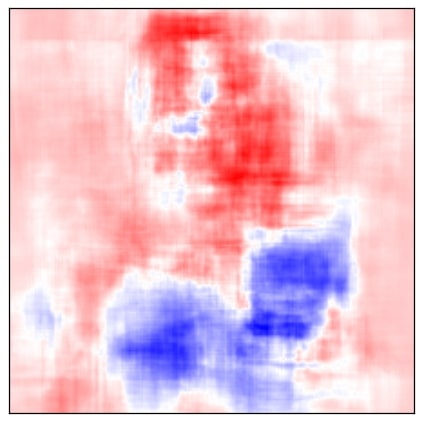

oclusão para **“gato”**

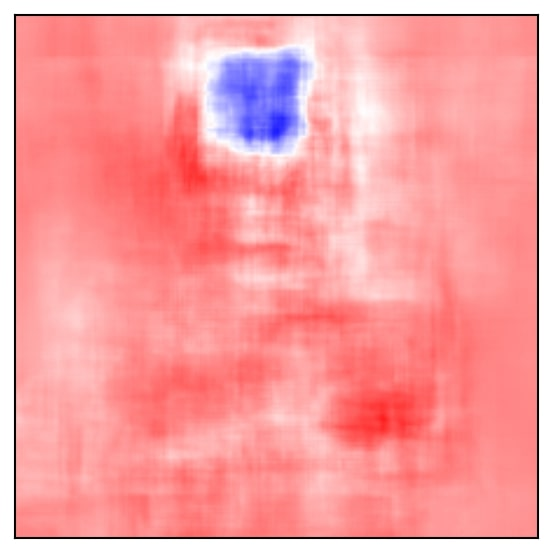

oclusão para **“buldogue”**

**Atenção às cores:** nestes dois mapas, **azul** marca onde tapar **derruba** o escore da classe — a evidência a favor dela. É o contrário dos nossos mapas, em que vermelho é a favor.

**Um mapa por classe**

Para “gato”, o azul fica sobre o gato; para “buldogue”, sobre a cabeça do cachorro. A mesma foto, duas perguntas, dois mapas.

**Caro**

Uma passada da VGG-16 por posição do bloco. O Grad-CAM, que veremos adiante, chega a mapas parecidos “orders of magnitude cheaper”.

[Selvaraju *et al.* (2020)](https://doi.org/10.1007/s11263-019-01228-7), fig. 1a, 1e e 1k (VGG-16; reproduzidas para fins didáticos); “in (e, k), blue corresponds to evidence for the class” (legenda da fig. 1).

## Da oclusão à derivada

Tapar muda o pixel de uma vez. Mudar só um pouco e dividir pela mudança dá a **taxa** com que o escore responde ao pixel: a derivada.

Diferença finita e derivada parcial: definições usuais do cálculo, aqui com a rede comum. A conta de um pixel por vez é a do gradiente numérico; a regra da cadeia (próximo slide) dá todos de uma vez.

## A função da rede comum

A rede é só uma função de três números, $y=f(x_1,x_2,x_3)$. Fixando pixels, dá para desenhá-la: a oclusão olha o valor em $x_i=0$; a derivada, a inclinação no ponto da imagem.

Contas da própria rede comum (filtros A e B, ReLU, saída linear). Redes de ReLUs como funções lineares por partes: [Montavon, Samek e Müller (2018)](https://doi.org/10.1016/j.dsp.2017.10.011), §7.1.

# Vanilla Gradient

## O gradiente como uma reta tangente

$$S_c(\mathbf x)\;\approx\;S_c(\mathbf x_0)+\nabla S_c(\mathbf x_0)\cdot(\mathbf x-\mathbf x_0)
\;=\;\mathbf w^\top\mathbf x+b,
\qquad \mathbf w=\frac{\partial S_c}{\partial\mathbf x}\Big|_{\mathbf x_0}$$

**$\mathbf x_0$**

A imagem explicada.

**$\nabla S_c(\mathbf x_0)=\mathbf w$**

Uma derivada por pixel, $w_i=\partial S_c/\partial x_i$: a inclinação da “tangente” em cada direção.

**$\mathbf w^\top\mathbf x+b$**

Perto de $\mathbf x_0$, a rede se comporta como um modelo linear; $w_i$ é o “coeficiente” do pixel $i$ ([Aula 04](https://brunogrisci.github.io/aulas-interpretabilidade/aula04.html)).

**$S_c$ antes do softmax**

Usa-se o logit: a probabilidade de $c$ também sobe se as outras classes caírem.

Expansão de Taylor de 1.ª ordem: [Simonyan, Vedaldi e Zisserman (2014)](https://arxiv.org/abs/1312.6034), eqs. (2)–(4) — que chamavam o método de *image-specific class saliency*; o nome Vanilla Gradient é de [Molnar (2025)](https://christophm.github.io/interpretable-ml-book/pixel-attribution.html#vanilla-gradient). Escore antes do softmax: Simonyan *et al.*, §2. A curva do interativo é ilustrativa.

## Regra da cadeia: multiplicar os elos, somar os caminhos

**Relembrando a [Aula 13](https://brunogrisci.github.io/aulas-interpretabilidade/aula13.html):** se $y$ depende de $u$ e $u$ depende de $x$, então $\dfrac{\partial y}{\partial x}=\dfrac{\partial y}{\partial u}\cdot\dfrac{\partial u}{\partial x}$. Com vários caminhos de $x$ até $y$, somam-se os produtos de cada caminho.

## Vanilla Gradient passo a passo

**1 · Forward**

Calcula e guarda as ativações para a imagem.

→

**2 · Uma classe**

Parte do escore $S_c$; as outras classes valem 0.

→

**3 · Backward**

Regra da cadeia até os **pixels**, não até os pesos.

→

**4 · Mostrar**

O mapa com sinal, ou o módulo $|\partial S_c/\partial x_i|$.

Receita: [Molnar (2025)](https://christophm.github.io/interpretable-ml-book/pixel-attribution.html#vanilla-gradient). Regra da cadeia e backpropagation: [Aula 13](https://brunogrisci.github.io/aulas-interpretabilidade/aula13.html).

## Qual classe explicar?

Um mapa explica um escore de cada vez. Na mesma imagem, $y_1$ dá (3, 0, −1), $y_2$ dá (−1, 3, 2) e a diferença $y_1-y_2$ dá (4, −3, −3).

Escore antes do softmax: [Simonyan, Vedaldi e Zisserman (2014)](https://arxiv.org/abs/1312.6034), §2. Explicar a diferença de dois escores: [Shrikumar, Greenside e Kundaje (2017)](https://arxiv.org/abs/1704.02685), §4.1. A segunda saída ($y_2$, com pesos $v'$) foi acrescentada à rede comum para este exemplo.

## Saliency map × feature visualization

[figure not shown]

**Feature visualization ([Aula 14](https://brunogrisci.github.io/aulas-interpretabilidade/aula14.html)): 1.ª linha**

Os pesos ficam fixos e a **imagem muda**: parte-se de um cinza com ruído e sobe-se $\nabla_{\mathbf x}S_c$ centenas de vezes, até achar a entrada que a classe “prefere”. Uma pergunta global: o que a rede procura em qualquer imagem da classe?

**Saliency map: 2.ª e 3.ª linhas**

A imagem fica **fixa**: calcula-se $\nabla_{\mathbf x}S_c$ uma vez, nela mesma, e lê-se pixel a pixel. Uma pergunta local: o que, nesta imagem, pesou para a classe?

O mesmo gradiente, dois usos: para mudar a entrada ou para lê-la. Simonyan *et al.* (2014) propuseram os dois no mesmo artigo.

[Simonyan, Vedaldi e Zisserman (2014)](https://arxiv.org/abs/1312.6034), §2 (*class model visualisation*) e §3 (*image-specific class saliency*); [Montavon, Samek e Müller (2018)](https://doi.org/10.1016/j.dsp.2017.10.011), §2–4. Reprodução na CNN da aula: imagens otimizadas para o logit de cada classe (Adam, 512 passos, deslocamento aleatório, blur e penalização L2, como na Aula 14); mapas do Vanilla Gradient da classe prevista.

## A CNN da aula

As reproduções no MNIST usam a mesma CNN pequena da [Aula 14](https://brunogrisci.github.io/aulas-interpretabilidade/aula14.html), treinada por nós em NumPy, com a retropropagação escrita à mão até os pixels.

[figure not shown]

**O que entra e o que sai**

Uma imagem 28 × 28 (784 pixels, de 0 a 1) e 10 escores (logits), um por dígito. Explica-se sempre um logit, antes do softmax.

**Até onde cada método volta**

Gradiente e regras da ReLU voltam até os pixels; o Grad-CAM para na conv2; a oclusão não volta: só passa para frente.

**O que os mapas explicam**

Esta rede, com os seus 98,66% de acerto — não “o MNIST” nem como um humano reconhece dígitos.

## No MNIST: sinal ou módulo?

**Com sinal**

Vermelho: aumentar o pixel aumentaria o escore; azul: diminuiria. O fundo preto também recebe valores: pôr tinta ali mudaria a decisão.

**Em módulo**

Só a força: “que pixels precisam mudar menos para mudar mais o escore”. Simonyan *et al.* usam $\max_{\text{canal}}|w_i|$ nas imagens coloridas.

**Ruidoso**

O mapa parece granulado: pixels vizinhos têm gradientes muito diferentes. Os próximos métodos tentam limpá-lo — com consequências.

CNN da aula (a mesma da Aula 14): conv 5 × 5 (16) → max-pool → conv 5 × 5 (32) → max-pool → densa 64 → 10 logits, 98,66% de acerto no teste. Primeira imagem de teste de cada dígito, sem escolha. Mapas na escala do percentil 99,5 de |R|. Citação: [Simonyan, Vedaldi e Zisserman (2014)](https://arxiv.org/abs/1312.6034), §3–3.1.

## Vanilla Gradient em fotos

[figure not shown]

**Como ler**

Em cada par, a foto em cima e o mapa embaixo: o módulo do gradiente da classe prevista, o maior entre os três canais de cor, $\max_{\text{canal}}|\partial S_c/\partial x_i|$. Claro = o pixel que, mudado, mais muda o escore.

**O que se vê**

O objeto aparece como uma nuvem de pontos claros: a rede é sensível aos pixels dele, mas o mapa é granulado — o problema que o SmoothGrad vai atacar.

[Simonyan, Vedaldi e Zisserman (2014)](https://arxiv.org/abs/1312.6034), fig. 2 e §3.1 (ConvNet própria no ILSVRC-2013; uma retropropagação por imagem; reproduzida para fins didáticos).

# DeconvNet e Guided Backprop

## Como o gradiente atravessa cada camada

Regra da cadeia em cada tipo de camada: [Aula 13](https://brunogrisci.github.io/aulas-interpretabilidade/aula13.html). DeconvNet = esta mesma volta (convolução com o filtro transposto, max-pooling pelos *switches*), exceto na ReLU: [Simonyan, Vedaldi e Zisserman (2014)](https://arxiv.org/abs/1312.6034), §4; [Zeiler e Fergus (2014)](https://arxiv.org/abs/1311.2901), §2.1.

## Três regras para atravessar a ReLU

No passo para trás, a ReLU decide o que passa. O gradiente olha o forward; o DeconvNet olha o sinal que volta; o Guided Backprop exige os dois.

**forward: entrada z**

| 1 | −1 | 5 |
| --- | --- | --- |
| 2 | −5 | −7 |
| −3 | 2 | 4 |

ReLU desliga onde z ≤ 0

**sinal que volta g**

| −2 | 3 | −1 |
| --- | --- | --- |
| 6 | −3 | 1 |
| 2 | −1 | 3 |

∂S/∂(saída da ReLU)

→

**gradiente**

| −2 | 0 | −1 |
| --- | --- | --- |
| 6 | 0 | 0 |
| 0 | −1 | 3 |

g · 1[z > 0]

**DeconvNet**

| 0 | 3 | 0 |
| --- | --- | --- |
| 6 | 0 | 1 |
| 2 | 0 | 3 |

g · 1[g > 0]

**Guided Backprop**

| 0 | 0 | 0 |
| --- | --- | --- |
| 6 | 0 | 0 |
| 0 | 0 | 3 |

g · 1[g > 0] · 1[z > 0]

**Gradiente**

A derivada de verdade: bloqueia onde a unidade estava desligada no forward.

**DeconvNet**

Zeiler e Fergus projetavam uma ativação de volta aos pixels: *unpooling* com os índices do máximo, ReLU no sinal e filtros transpostos. Só a ReLU difere do gradiente.

**Guided Backprop**

Zera o que não estava ligado **ou** puxava para baixo: guarda os pixels que *excitam* a classe, nunca os que a inibem. Não é mais uma derivada.

Exemplo numérico da fig. 1 de [Springenberg *et al.* (2015)](https://arxiv.org/abs/1412.6806) (azul: negativo; cinza: zerado). DeconvNet: [Zeiler e Fergus (2014)](https://arxiv.org/abs/1311.2901), §2.1; equivalência com o gradiente “apart from the RELU layer”: [Simonyan *et al.* (2014)](https://arxiv.org/abs/1312.6034), §4; [Molnar (2025)](https://christophm.github.io/interpretable-ml-book/pixel-attribution.html#deconvnet).

## As três regras na rede comum

Só muda o que acontece na ReLU: a mesma rede dá (3, 0, −1), (3, 3, −2) ou (3, 1, 0). As duas modificações apagam as contribuições negativas — os mapas ficam mais “limpos” e mais positivos.

## No MNIST: bonito, mas de qual classe?

**Pouco discriminativo**

Em 200 imagens de teste, a correlação de Spearman ([Aula 02](https://brunogrisci.github.io/aulas-interpretabilidade/aula02.html)) entre o mapa da classe prevista e o da segunda mais provável tem mediana −0,00 no gradiente, 0,56 no DeconvNet e **0,79 no Guided Backprop**: mude a classe e o mapa quase não muda.

**Um alerta**

Os mapas mais nítidos lembram um detector de bordas. Um mapa que não depende da classe também pode não depender da rede: é o que os sanity checks testam ([Aula 16](https://brunogrisci.github.io/aulas-interpretabilidade/aula16.html)) .

“Visualizations with respect to different classes are nearly identical”: [Selvaraju *et al.* (2020)](https://doi.org/10.1007/s11263-019-01228-7), p. 3. Reprodução: imagens de teste 0 a 199, mapas da 1.ª e da 2.ª classe com maior logit, correlação de postos sobre os 784 pixels.

## Gradiente, DeconvNet e Guided Backprop numa foto

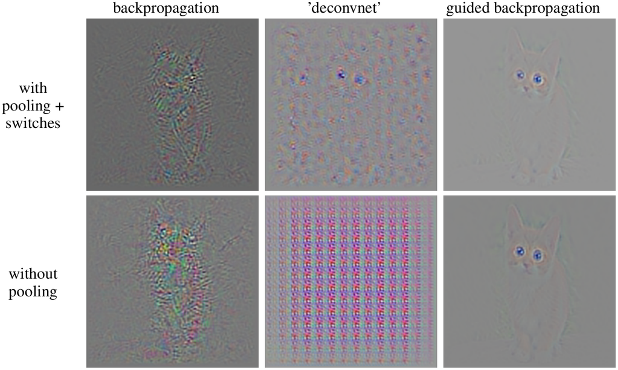

**Como ler**

Colunas: as três regras da ReLU. Linhas: com max-pooling (usando os *switches*) e sem pooling. As cores são a reconstrução na imagem: cinza = 0.

**O que se vê**

O Guided Backprop dá o gato mais nítido, com ou sem pooling; o DeconvNet “fails completely in the absence of switches”. Nitidez, porém, não é prova de fidelidade (Aula 16).

[Springenberg *et al.* (2015)](https://arxiv.org/abs/1412.6806), fig. 5 e p. 9 (All-CNN no ImageNet, maior ativação da camada final antes do softmax; reproduzida para fins didáticos).

# SmoothGrad

## O gradiente é ruidoso

[figure not shown]

**Por quê**

Uma rede de ReLUs é linear por partes: dentro de cada pequena região o gradiente é constante, e ele **salta** quando alguma unidade liga ou desliga. Andando um pouco na imagem, cruzam-se muitas dessas fronteiras.

**Consequência**

“The derivative of the function $S_c$ may fluctuate sharply at small scales”: parte do granulado do mapa é uma variação local sem significado, e não informação sobre a decisão.

Reprodução da fig. 2 de [Smilkov *et al.* (2017)](https://arxiv.org/abs/1706.03825) na CNN da aula: o 3 da imagem de teste 18 e uma direção ε sorteada (normal, desvio 0,05 por pixel; o artigo usa 0,01 no ImageNet); os 3 pixels de maior |gradiente| em t = 0, com a derivada dividida pelo maior |gradiente| da imagem. Citação: Smilkov *et al.*, §2.

## SmoothGrad: tirar ruído pondo ruído

$$R_{\text{sg}}(\mathbf x)=\frac1N\sum_{i=1}^{N}R(\mathbf x+\mathbf g_i),
\qquad \mathbf g_i\sim\mathcal N(0,\sigma^2)$$

[interactive chart not shown]

uma cópia com ruído (σ escolhido)

[interactive chart not shown]

Vanilla Gradient (σ = 0)

[interactive chart not shown]

**$R(\cdot)$**

Qualquer mapa: Vanilla Gradient aqui, mas também Guided Backprop ou outros. SmoothGrad é um “invólucro”.

**$\mathbf g_i$**

Ruído gaussiano somado a cada pixel, sorteado de novo em cada cópia.

**$\sigma$**

Proporção da faixa de intensidades, $\sigma/(x_{\max}-x_{\min})$: 10–20% segundo os autores.

**$N$**

Número de cópias: pouca mudança acima de 50.

[Smilkov *et al.* (2017)](https://arxiv.org/abs/1706.03825), §2.2 e §3.2–3.4; [Molnar (2025)](https://christophm.github.io/interpretable-ml-book/pixel-attribution.html#smoothgrad). Média do gradiente nas vizinhanças = gradiente da rede “borrada” por uma gaussiana: o SmoothGrad explica uma versão suavizada da rede. Reprodução: dígitos 3 e 8 das imagens de teste 18 e 61.

## SmoothGrad na rede comum

Com σ = 1, várias cópias trocam alguma unidade de estado, e o mapa médio deixa de ser o gradiente de um ponto só: é a inclinação média da rede numa vizinhança. Com σ = 0, as cópias são iguais e o SmoothGrad é o Vanilla Gradient.

50 cópias com ruído gaussiano sorteado com semente fixa; o mesmo sorteio para todos os σ. Na rede comum, a faixa de intensidades é x<sub>máx</sub> − x<sub>mín</sub> = 2, então σ = 0,25 corresponde aos 12,5% da recomendação de Smilkov *et al.* (2017).

## SmoothGrad em fotos

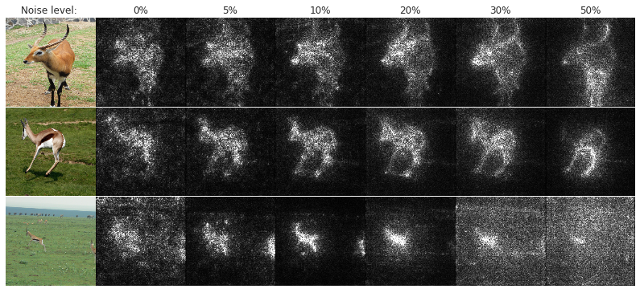

**Como ler**

Cada coluna é o SmoothGrad com um nível de ruído σ (em % da faixa de intensidades), N = 50 cópias. A coluna 0% é o Vanilla Gradient. Mapas em módulo: claro = sensível.

**O que se vê**

“Applying 10%-20% noise (middle columns) seems to balance the sharpness of sensitivity map and maintain the structure of the original image.” Pouco ruído não limpa; ruído demais apaga o objeto.

[Smilkov *et al.* (2017)](https://arxiv.org/abs/1706.03825), fig. 3 e p. 4 (Inception v3 no ILSVRC-2013; reproduzida para fins didáticos).

# Grad-CAM

## Olhar a última camada convolucional

[figure not shown]

$$\alpha^c_k=\underbrace{\frac1Z\sum_{i}\sum_{j}}_{\text{média espacial}}\underbrace{\frac{\partial y^c}{\partial A^k_{ij}}}_{\text{backprop}},
\qquad
L^c_{\text{Grad-CAM}}=\mathrm{ReLU}\Big(\sum_k\alpha^c_k\,A^k\Big)$$

**$A^k$**

O $k$-ésimo mapa de ativação da última camada convolucional; $A^k_{ij}$, o valor na posição $(i,j)$.

**$y^c$**

O escore da classe $c$ antes do softmax.

**$Z$**

O número de posições do mapa ($u\times v$, por exemplo 14 × 14).

**$\alpha^c_k$**

O peso do mapa $k$ para a classe $c$: quanto o canal inteiro empurra $y^c$.

**ReLU**

Guarda só as regiões que **aumentam** $y^c$.

[Selvaraju *et al.* (2020)](https://doi.org/10.1007/s11263-019-01228-7), §3, eqs. (1)–(2) e fig. 2 (redesenhada); [Molnar (2025)](https://christophm.github.io/interpretable-ml-book/pixel-attribution.html#grad-cam).

## Grad-CAM passo a passo

Grad-CAM (Gradient-weighted Class Activation Mapping) não volta até os pixels: o mapa tem a resolução da camada (2 posições aqui, 14 × 14 numa VGG) e é ampliado. Ganha discriminação entre classes, perde detalhe.

## Grad-CAM no MNIST

1 · os 32 canais A<sup>k</sup> da conv2 (14 × 14), do maior ao menor α<sub>k</sub>

[interactive chart not shown]

2 · Σ<sub>k</sub> α<sub>k</sub>A<sup>k</sup>

→

[interactive chart not shown]

3 · ReLU

→

[interactive chart not shown]

4 · ampliado (bilinear) sobre o dígito

Grad-CAM na conv2 da CNN da aula (32 mapas de 14 × 14, após a ReLU, antes do max-pooling). Tons de cinza dos canais: ativação de 0 ao máximo da imagem. Mapas 2–4: vermelho positivo, azul negativo, na escala de cada mapa.

## Por que essas escolhas?

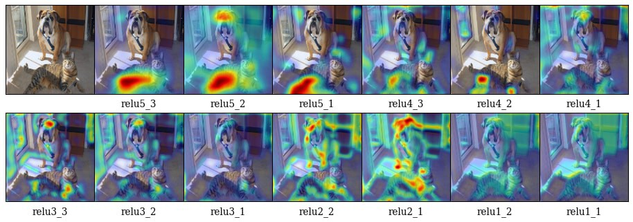

Grad-CAM da classe “gato” em cada camada da VGG-16, da última convolucional (relu5_3) à primeira (relu1_1).

**A última camada**

É o melhor compromisso entre semântica (partes, objetos) e informação espacial. Nas camadas iniciais, o mapa fica espalhado.

**A ReLU e a média**

Sem a ReLU, o erro de localização top-1 sobe de 59,65% para 74,98%; com o máximo dos gradientes em vez da média, 59,96%.

**CAM é um caso particular**

Se a rede termina em $y^c=\sum_k w^c_k\frac1Z\sum_{ij}A^k_{ij}$, então $\partial y^c/\partial A^k_{ij}=w^c_k/Z$ e $\alpha^c_k\propto w^c_k$: os pesos do CAM, sem retreinar a rede.

[Selvaraju *et al.* (2020)](https://doi.org/10.1007/s11263-019-01228-7): fig. 13 (reproduzida para fins didáticos) e §3; tab. 3 (VGG-16, ILSVRC-15, avaliação com 10 recortes); §3.1, eqs. (3)–(11), para o CAM. CAM: [Zhou *et al.* (2016)](https://arxiv.org/abs/1512.04150), que exige a arquitetura convolução → global average pooling → softmax.

## Guided Grad-CAM

Grad-CAM diz *onde*, com resolução grosseira; Guided Backprop dá o detalhe, sem distinguir classes. O produto, pixel a pixel, tem os dois.

**“gato”**

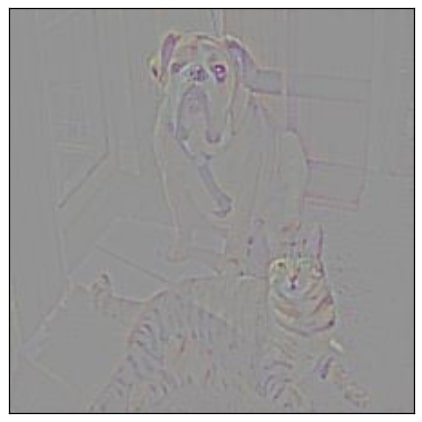

Guided Backprop

Grad-CAM

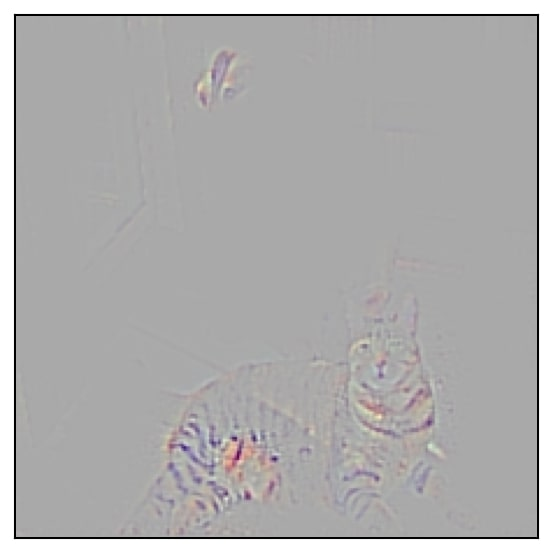

Guided Grad-CAM

**“buldogue”**

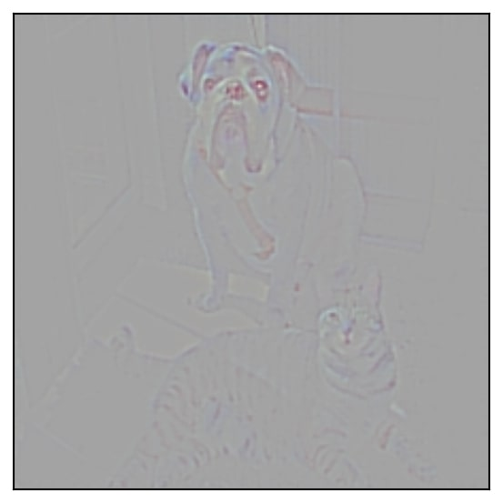

Guided Backprop

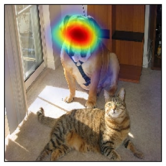

Grad-CAM

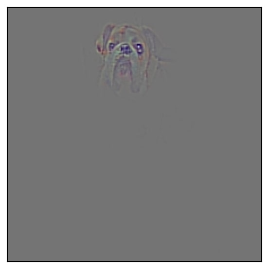

Guided Grad-CAM

Na rede comum: (3, 1, 0) ⊙ (4; 2,5; 1) = (12; 2,5; 0). Num teste com 43 pessoas, quem via Guided Grad-CAM acertou a classe mostrada em 61,23% das vezes; com Guided Backprop, 44,44%.

[Selvaraju *et al.* (2020)](https://doi.org/10.1007/s11263-019-01228-7), fig. 1b–d e 1h–j (reproduzidas para fins didáticos), §3.2 e tab. 2 (§5.1, PASCAL VOC 2007); [Molnar (2025)](https://christophm.github.io/interpretable-ml-book/pixel-attribution.html#guided-grad-cam): o Grad-CAM funciona como uma lente sobre o mapa de pixels.

## Grad-CAM contrafactual

**imagem**

[figure not shown]

contrafactual para **“gato”**

[figure not shown]

contrafactual para **“buldogue”**

$$\alpha'^{\,c}_k=\frac1Z\sum_i\sum_j\Big(-\frac{\partial y^c}{\partial A^k_{ij}}\Big),\qquad L^c_{\text{contrafactual}}=\mathrm{ReLU}\Big(\sum_k\alpha'^{\,c}_k A^k\Big)$$

Trocar o sinal do gradiente mostra o que vai **contra** a classe: para “gato”, o cachorro; para “buldogue”, o gato. Segundo os autores, removê-las deixaria a rede mais confiante — o próximo slide testa isso. Na rede comum (aba 8 do passo a passo), nada vai contra y: o mapa é (0, 0).

[Selvaraju *et al.* (2020)](https://doi.org/10.1007/s11263-019-01228-7), §3.3, eq. (12) e fig. 3 (reproduzida para fins didáticos; mapa de cores *jet*: vermelho = alto, azul = baixo): “removing concepts occurring in those regions would make the model more confident about its prediction”.

## Reprodução: o contrafactual na nossa CNN

[figure not shown]

**Como ler**

Em cada linha: o dígito, o Grad-CAM da classe prevista c, o contrafactual de c (eq. 12) e o Grad-CAM da 2.ª classe. Mesma escala na linha: branco = 0, vermelho = o máximo.

**A promessa não se confirmou aqui**

Zerar a conv2 na região contrafactual aumentou $y^c$ em só 16,9% de 978 imagens; uma região sorteada do mesmo tamanho, em 9,5%. O α é a média do gradiente no canal inteiro; ali, o gradiente local muitas vezes tem o sinal oposto.

CNN da aula, conv2; imagens de teste 18, 8, 61 e 7. O 9 tem Grad-CAM quase branco: evidência fraca (p = 77,7%). Remoção (teste nosso; o artigo só mostra exemplos): 1.000 imagens, região acima de 15% do máximo; contrafactual vazio em 22 delas.

## Como avaliar o Grad-CAM?

| teste | como | resultado |
| --- | --- | --- |
| localização | caixa em volta da maior região acima de 15% do máximo, comparada com a caixa anotada (ILSVRC-15) | erro top-1 de 56,51% (VGG-16), contra 61,12% do gradiente e 57,20% do CAM |
| *pointing game* | o ponto máximo do mapa cai dentro do objeto? | 70,58%, contra 60,30% do c-MWP |
| pessoas | 43 pessoas dizem qual classe o mapa mostra | 61,23% com Guided Grad-CAM, 44,44% com Guided Backprop |
| fidelidade | correlação de postos com o mapa de oclusão (2.510 imagens do PASCAL) | Grad-CAM 0,254; Guided Grad-CAM 0,261; Guided Backprop 0,168 |

**O que mede cada um**

Localização e *pointing game* medem se o mapa cai sobre o objeto; o teste com pessoas, se o mapa é compreensível; só o último compara com o que a rede faz (a oclusão).

**Um alerta**

Cair sobre o objeto não prova que a rede usou o objeto. “A more faithful visualization is typically less interpretable.” A [Aula 16](https://brunogrisci.github.io/aulas-interpretabilidade/aula16.html) volta a essa pergunta: como testar se um mapa é fiel?

[Selvaraju *et al.* (2020)](https://doi.org/10.1007/s11263-019-01228-7), tab. 1 (p. 6), §4.3 (p. 7), §5.1–5.3 e tab. 2 (pp. 7–8). O artigo informa o *pointing game* com a GoogLeNet ajustada no COCO (nota 4) e com a VGG-16 (Apêndice D).

## Grad-CAM para encontrar vieses

[figure not shown]

**O modelo enviesado**

Uma VGG-16 treinada com as primeiras imagens de uma busca por “doctor” e “nurse” (78% homens e 93% mulheres): o Grad-CAM mostra que ela olha para o rosto e o cabelo.

**Depois de rebalancear**

Com o mesmo número de enfermeiros homens e médicas mulheres no treino, o modelo passa a olhar o jaleco e o estetoscópio; o acerto no teste sobe de 82% para 90%.

O mesmo artigo mostra erros com mapas “razoáveis”: “seemingly unreasonable predictions have reasonable explanations”. Um mapa convincente também pode justificar um erro.

[Selvaraju *et al.* (2020)](https://doi.org/10.1007/s11263-019-01228-7), §6.3 e fig. 8 (reproduzida para fins didáticos; nas legendas, caixa vermelha: modelo enviesado; verde: corrigido); citação: §6.1 e fig. 6.

## Grad-CAM além da classificação

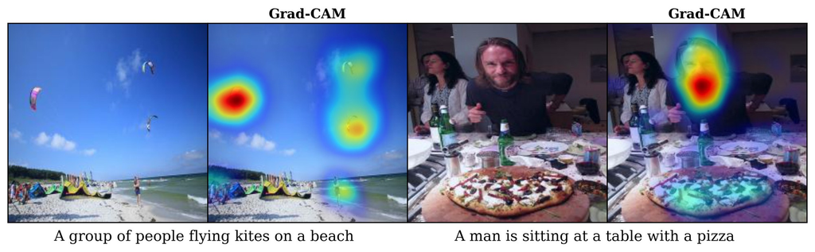

**Como funciona**

O escore $y^c$ pode ser qualquer número que a rede produz: aqui, a log-probabilidade da legenda gerada (VGG-16 + LSTM). O resto da receita não muda.

**O que se vê**

O mapa acha as pipas e as pessoas, mesmo pequenas; na segunda foto, destaca o homem e a pizza e ignora a mulher, “since ‘woman’ is not mentioned in the caption”.

[Selvaraju *et al.* (2020)](https://doi.org/10.1007/s11263-019-01228-7), fig. 10a e p. 11 (neuraltalk2; reproduzida para fins didáticos; mapa de cores *jet*: vermelho = alto). O mesmo artigo usa o Grad-CAM em perguntas e respostas visuais (VQA, fig. 12).

# Exemplos

## Três fotos, três métodos

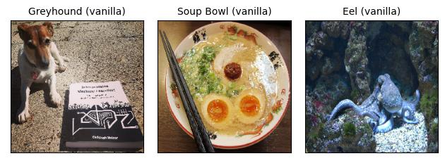

VGG-16: **greyhound** (35%), **soup bowl** (50%) e **eel** (70%) — o polvo foi classificado como enguia.

**“It’s a bit of a mess”**

Os métodos discordam entre si, e o Grad-CAM do cachorro aponta para o livro. Qual está certo? “We just do not know”: não há gabarito.

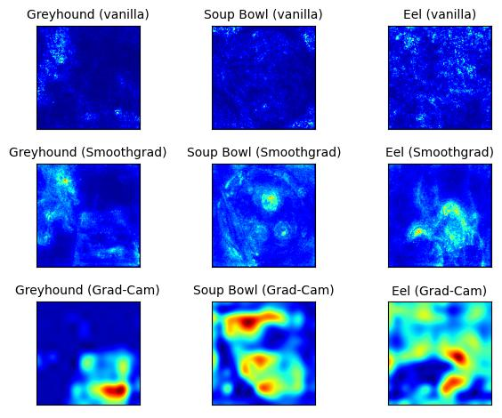

[Molnar (2025), *Examples*](https://christophm.github.io/interpretable-ml-book/pixel-attribution.html#examples): VGG-16 do ImageNet, mapas da classe de maior escore calculados com a biblioteca tf-keras-vis (figuras do livro; mapa de cores *jet*: azul baixo, vermelho alto).

## Na rede comum: seis mapas

Seis métodos, seis mapas para a mesma decisão. Eles concordam que x₁ ajuda; discordam sobre x₂ e x₃ — e nenhum diz *quanto* de y = 4 vem de cada pixel.

## Reprodução: os métodos de hoje no MNIST

CNN da aula; oclusão com bloco 4 × 4 preto; SmoothGrad com σ = 15% e N = 50; Grad-CAM e Guided Grad-CAM na conv2. Troque o dígito e a classe explicada: o Guided Backprop quase não muda com a classe.

# Limites do gradiente

## Quando o gradiente se cala

**Saturação**

Um pixel pode ter levado o escore de 0 a 1 e, ainda assim, ter gradiente 0: a rede já “saturou” e mexer mais nele não muda nada.

**A ideia da próxima aula**

Comparar com uma **referência** $\mathbf x'$ e dividir a diferença $S_c(\mathbf x)-S_c(\mathbf x')$ entre os pixels: LRP, DeepLIFT, Integrated Gradients — e a ligação com os valores de Shapley.

$f(x)=1-\mathrm{ReLU}(1-x)$ com referência 0 e entrada 2: [Sundararajan, Taly e Yan (2017)](https://arxiv.org/abs/1703.01365), §2.1; a mesma função, com $x=i_1+i_2$, na fig. 1 de [Shrikumar, Greenside e Kundaje (2017)](https://arxiv.org/abs/1704.02685); [Molnar (2025)](https://christophm.github.io/interpretable-ml-book/pixel-attribution.html#vanilla-gradient).

## Síntese

| método | o que volta pela rede | regra na ReLU | resolução | muda com a classe? |
| --- | --- | --- | --- | --- |
| oclusão | nada: só passadas para frente | — | bloco | sim |
| Vanilla Gradient | o gradiente $\partial S_c/\partial\mathbf x$ | passa se z > 0 | pixel | sim |
| DeconvNet | um sinal “reconstruído” | passa se o sinal > 0 | pixel | pouco |
| Guided Backprop | só o que excita | as duas condições | pixel | quase nada |
| SmoothGrad | média de N mapas com ruído | a do método de base | pixel | como o de base |
| Grad-CAM | o gradiente até a última conv | passa se z > 0 | camada (grosseira) | sim |
| Guided Grad-CAM | Grad-CAM ⊙ Guided Backprop | — | pixel | sim |

Todos respondem à mesma pergunta local — “o que mudaria a decisão perto desta imagem?” — e nenhum tem gabarito. Na Aula 16: métodos com referência, a ligação com Shapley, texto e tabelas, e como testar se um mapa é fiel à rede.

## Reprodutibilidade

Todas as reproduções foram escritas em NumPy, com a retropropagação até a entrada escrita à mão e a regra da ReLU trocável; semente 2026 e uma thread de BLAS.

| experimento | dados | modelo e protocolo | resultado |
| --- | --- | --- | --- |
| rede comum | x = (3, 1, 3) | conv 2 filtros de largura 2 → ReLU → saída linear; contas em frações exatas | y = 4; mapas inteiros ou meios |
| CNN da aula | MNIST 60 mil / 10 mil | conv 5 × 5 (16) → conv 5 × 5 (32) → 64 → 10; Adam, 3 épocas (a da Aula 14) | 98,66% no teste |
| galerias | 1.ª imagem de teste de cada dígito | logit das 3 classes mais prováveis; escala no percentil 99,5 | — |
| oclusão | dígitos 3 e 8 | blocos 2, 4 e 7 px, passo 1, preto ou cinza (0,5) | — |
| SmoothGrad | idem | σ de 0 a 50%, N de 1 a 100; mesmo ruído para todos os σ | — |
| Grad-CAM | idem | conv2 após a ReLU, 32 × 14 × 14; ampliação bilinear | mapa vazio em 3 de 1.000 imagens |
| Grad-CAM contrafactual | 1.000 imagens de teste | eq. (12) na conv2; zerar a região acima de 15% do máximo × uma região sorteada | y<sup>c</sup> sobe em 16,9% (sorteio: 9,5%) |
| discriminação | 200 imagens de teste | Spearman entre os mapas da 1.ª e da 2.ª classe | mediana: gradiente −0,00; Guided Backprop 0,79 |

Os interativos só leem resultados pré-calculados, exceto os da rede comum, que refazem as contas no navegador. Figuras de deep learning (VGG-16, ResNet, ImageNet): dos artigos originais e do livro de Molnar.

# Referências

## Referências I

- Molnar, C. (2025). [*Interpretable Machine Learning*](https://christophm.github.io/interpretable-ml-book/). 3. ed. Capítulo [*Saliency Maps*](https://christophm.github.io/interpretable-ml-book/pixel-attribution.html).
- Selvaraju, R. R.; Cogswell, M.; Das, A.; Vedantam, R.; Parikh, D.; Batra, D. (2020). [Grad-CAM: visual explanations from deep networks via gradient-based localization](https://doi.org/10.1007/s11263-019-01228-7). *International Journal of Computer Vision*, 128(2), 336–359. Versão de conferência: *ICCV 2017*.
- Montavon, G.; Samek, W.; Müller, K.-R. (2018). [Methods for interpreting and understanding deep neural networks](https://doi.org/10.1016/j.dsp.2017.10.011). *Digital Signal Processing*, 73, 1–15.
- Simonyan, K.; Vedaldi, A.; Zisserman, A. (2014). [Deep inside convolutional networks: visualising image classification models and saliency maps](https://arxiv.org/abs/1312.6034). *ICLR 2014 Workshop*.
- Zeiler, M. D.; Fergus, R. (2014). [Visualizing and understanding convolutional networks](https://doi.org/10.1007/978-3-319-10590-1_53). *ECCV 2014*, 818–833.

## Referências II

- Springenberg, J. T.; Dosovitskiy, A.; Brox, T.; Riedmiller, M. (2015). [Striving for simplicity: the all convolutional net](https://arxiv.org/abs/1412.6806). *ICLR 2015 Workshop*.
- Smilkov, D.; Thorat, N.; Kim, B.; Viégas, F.; Wattenberg, M. (2017). [SmoothGrad: removing noise by adding noise](https://arxiv.org/abs/1706.03825). *arXiv:1706.03825*.
- Zhou, B.; Khosla, A.; Lapedriza, A.; Oliva, A.; Torralba, A. (2016). [Learning deep features for discriminative localization](https://arxiv.org/abs/1512.04150). *CVPR 2016*.
- Bach, S.; Binder, A.; Montavon, G.; Klauschen, F.; Müller, K.-R.; Samek, W. (2015). [On pixel-wise explanations for non-linear classifier decisions by layer-wise relevance propagation](https://doi.org/10.1371/journal.pone.0130140). *PLoS ONE*, 10(7), e0130140.
- Alber, M. *et al.* (2019). [iNNvestigate neural networks!](https://jmlr.org/papers/v20/18-540.html) *Journal of Machine Learning Research*, 20(93), 1–8.

## Referências III

- Adebayo, J.; Gilmer, J.; Muelly, M.; Goodfellow, I.; Hardt, M.; Kim, B. (2018). [Sanity checks for saliency maps](https://arxiv.org/abs/1810.03292). *NeurIPS 31*.
- Sundararajan, M.; Taly, A.; Yan, Q. (2017). [Axiomatic attribution for deep networks](https://arxiv.org/abs/1703.01365). *ICML 2017*.
- Shrikumar, A.; Greenside, P.; Kundaje, A. (2017). [Learning important features through propagating activation differences](https://arxiv.org/abs/1704.02685). *ICML 2017*.
- Itti, L.; Koch, C.; Niebur, E. (1998). [A model of saliency-based visual attention for rapid scene analysis](https://doi.org/10.1109/34.730558). *IEEE TPAMI*, 20(11), 1254–1259.
- Simonyan, K.; Zisserman, A. (2015). [Very deep convolutional networks for large-scale image recognition](https://arxiv.org/abs/1409.1556). *ICLR 2015*. (*VGG-16*)
- Kokhlikyan, N. *et al.* (2020). [Captum: a unified and generic model interpretability library for PyTorch](https://arxiv.org/abs/2009.07896). *arXiv:2009.07896*.

## Referências IV

- Priem, J.; Piwowar, H.; Orr, R. (2022). [OpenAlex: a fully-open index of scholarly works, authors, venues, institutions, and concepts](https://arxiv.org/abs/2205.01833). *arXiv:2205.01833*.
- LeCun, Y.; Cortes, C.; Burges, C. J. C. [*The MNIST database of handwritten digits*](http://yann.lecun.com/exdb/mnist/).
- Kingma, D. P.; Ba, J. (2015). [Adam: a method for stochastic optimization](https://arxiv.org/abs/1412.6980). *ICLR 2015*.
- Harris, C. R. *et al.* (2020). [Array programming with NumPy](https://doi.org/10.1038/s41586-020-2649-2). *Nature*, 585, 357–362.
- Figuras reproduzidas para fins didáticos: [Selvaraju *et al.* (2020)](https://doi.org/10.1007/s11263-019-01228-7), figs. 1, 8 e 13 (versão do arXiv, imagens extraídas do PDF sem reamostragem); [Molnar (2025)](https://christophm.github.io/interpretable-ml-book/pixel-attribution.html), figuras do capítulo *Saliency Maps*.

## Próxima aula

**[Aula 16: Saliency e Atribuição em Redes Neurais II](https://brunogrisci.github.io/aulas-interpretabilidade/aula16.html)**

## Sobre os slides

Slides por [Bruno Iochins Grisci](https://brunogrisci.github.io/) com base nas referências da disciplina, em especial o livro [*Interpretable Machine Learning: A Guide for Making Black Box Models Explainable*](https://christophm.github.io/interpretable-ml-book/). 3. ed. (2025) por [Christoph Molnar](https://christophmolnar.com/). Nesta aula, também os artigos [*Grad-CAM: Visual Explanations from Deep Networks via Gradient-based Localization*](https://doi.org/10.1007/s11263-019-01228-7) (2020), de Ramprasaath R. Selvaraju, Michael Cogswell, Abhishek Das, Ramakrishna Vedantam, Devi Parikh e Dhruv Batra, e [*Methods for Interpreting and Understanding Deep Neural Networks*](https://doi.org/10.1016/j.dsp.2017.10.011) (2018), de Grégoire Montavon, Wojciech Samek e Klaus-Robert Müller.

Slides desenvolvidos usando [Quarto](https://quarto.org/) e [reveal.js](https://revealjs.com/) com auxílio de Claude Code e Opus 5.5.

## Licença e direitos autorais

© 2026 [Bruno Iochins Grisci](https://brunogrisci.github.io/). Alguns direitos reservados.

Exceto quando indicado em contrário, os textos, diagramas e demais elementos autorais próprios desta apresentação estão licenciados sob a Licença Creative Commons Atribuição–NãoComercial 4.0 Internacional (CC BY-NC 4.0):

https://creativecommons.org/licenses/by-nc/4.0/deed.pt-br

É permitida a cópia e o compartilhamento do material, para fins não comerciais, mediante atribuição adequada da autoria.

Imagens, citações, marcas, logotipos e demais materiais de terceiros não estão abrangidos por esta licença e permanecem sujeitos às respectivas licenças e direitos autorais indicados junto a cada item.

Para uso comercial, adaptações ou outras permissões, entre em contato com o [autor](https://brunogrisci.github.io/).